# Lecture 14 Notes

# Sequence alignment, variant discovery, and variant annotation

## Rpackages for today

We’ll need the following packages from Bioconductor. Install them with `BiocManager::install` if you don’t have them already.

```r
library(GenomicFeatures)   # should have from previous weeks
library(VariantAnnotation) # new
library(ggbio)             # new
```

## Files for today

We’ll work today with four FASTQ files from Thurber et al. (2013; doi:10.1186/gb-2013-14-6-r68). These were part of a study to determine genetic variation involved in climatic adaptation in sorghum. Genomic DNA was digested with the restriction enzyme *Pst*I, then DNA adjacent to the cut sites was sequenced. Each file represents one sample. The four files can be downloaded from Compass, or to get them more quickly you can go to Run again and launch

`\\ad.uillinois.edu\aces\Courses\CPSC\499\Fall 18\Students\sorghum`

Also, download the files `Sbicolor_454_v3.0.1.hardmasked.fa.gz` and `Sbicolor_454_v3.1.1.gene_exons.gff3.gz` from Compass. These are the reference genome and annotation, respectively.

Put all of these files into a folder that is shared with the Ubuntu virtual machine. You can leave the FASTQ files as they are, but unzip the reference genome files from the Ubuntu terminal:

```
gunzip Sbicolor_454_v3.0.1.hardmasked.fa.gz
gunzip Sbicolor_454_v3.1.1.gene_exons.gff3.gz
```

## Building an index for sequence alignment with Bowtie2

From the Ubuntu Terminal, run the command:

```
bowtie2-build Sbicolor_454_v3.0.1.hardmasked.fa Sbi3
```

(8 minutes)

You’ll see we called the `bowtie2-build` command with two arguments. The first was the name of the file containing the reference genome sequence. The second, `Sbi3`, is just a shorthand that we’ll use for this reference genome. `Sbi3` will be used as a prefix for the file names containing the index.

In the folder with your reference genome you should now see the files Sbi3.1.bt2, Sbi3.2.bt2, Sbi3.3.bt2, Sbi3.4.bt2, Sbi3.rev.1.bt2, and Sbi3.rev.2.bt2. You’ll never have to make those six files again (until a new version of the genome comes out); you can use them as many times as you want for doing alignments.

## Making sequence alignments for your FASTQ files

Now, to align our FASTQ files to the genome, we’ll call `bowtie2` once per file. Create the following bash script to run Bowtie2 in a loop:

```bash
#!/bin/bash

for i in 1957 2051 2330 2519
do
bowtie2 -x Sbi3 -U SRR87${i}.fastq.gz -S SRR87${i}.sam
done
```

(Don’t run it yet. We will add more to this script.)

What are the arguments here? `-x Sbi3` indicates that the index to use is our *Sorghum bicolor* v3 index. `-U SRR871957.fastq.gz` indicates that we are using unpaired (single-end) reads and shows Bowtie2 where to find the FASTQ file for those reads. `-S SRR871957.sam` indicates the name of the output file. There are other arguments if you have paired-end reads or if you want to change the sensitivity of the alignment. See `bowtie2 --help` for a list of all arguments.

## Converting to BAM, sorting and indexing

The SAM files are in the same order as the original FASTQ files, which is random with respect to actual genomic positions.

```
head SRR871957.sam
```

By converting to BAM format, we can sort the files by chromosome and position instead. We can also index the file so that we can quickly pull data out of it by chromosome and position.

Below are some commands using Samtools to convert the SAM files to BAM files, sort the BAM files by position, then index them. We’ll add this code to our alignment script so we can do everything at once. The whole script will take about a half hour to run on our virtual Ubuntu machines.

```bash
#!/bin/bash

for i in 1957 2051 2330 2519
do
bowtie2 -x Sbi3 -U SRR87${i}.fastq.gz -S SRR87${i}.sam
samtools view -bS SRR87${i}.sam | samtools sort -o SRR87${i}.bam
samtools index SRR87${i}.bam
done
```

Now we will run this script in Linux using `sh`.

## Variant calling with samtools

Although we already made an index of the reference genome for Bowtie2, we’ll make another index that is specific for samtools using the `faidx` command.

```
samtools faidx Sbicolor_454_v3.0.1_hardmasked.fa
```

(1 minute)

```
samtools mpileup -g -r Chr01:10000000-15000000 -f Sbicolor_454_v3.0.1.hardmasked.fa SRR871957.bam SRR872051.bam SRR872330.bam SRR872519.bam > sorghum_small_pileup.bcf
```

In samtools there’s another executable called bcftools with a command called `call` that will do the actual SNP calling.

```
bcftools call -c -o sorghum_small_var.bcf sorghum_small_pileup.bcf
```

A Perl script called vcfutils.pl is then used for SNP filtering. This script is probably somewhere on our computers with the installation of Samtools, but can also just be downloaded at https://raw.githubusercontent.com/samtools/bcftools/develop/misc/vcfutils.pl.

```
bcftools view sorghum_small_var.bcf | vcfutils.pl varFilter -D100 > sorghum_small_filtered.vcf
```

Open up your VCF file using the `less` command and take a look at the contents. Press `q` to exit.

## Importing the VCF into R

Now we’ll start working in R.

Load the genome so we can get some information about chromosome lengths. The `FaFile` function will actually make use of the index that we build with `samtools faidx`.

```r
sorghum_genome <- FaFile("Sbicolor_454_v3.0.1.hardmasked.fa")
seqinfo(sorghum_genome)
```

```
## Seqinfo object with 870 sequences from an unspecified genome:
##   seqnames  seqlengths isCircular genome
##   Chr01       80884392       <NA>   <NA>
##   Chr02       77742459       <NA>   <NA>
##   Chr03       74386277       <NA>   <NA>
##   Chr04       68658214       <NA>   <NA>
##   Chr05       71854669       <NA>   <NA>
##   ...              ...        ...    ...
##   super_971       6094       <NA>   <NA>
##   super_979       6014       <NA>   <NA>
##   super_984       5980       <NA>   <NA>
##   super_99       52422       <NA>   <NA>
##   super_991       5961       <NA>   <NA>
```

Import your VCF file into R.

```r
sorghumVCF <- readVcf("sorghum_small_filtered.vcf", seqinfo(sorghum_genome))
```

The `header` function can be used to see some basic information.

```r
header(sorghumVCF)
```

```
## class: VCFHeader
## samples(4): SRR871957.bam SRR872051.bam SRR872330.bam
##   SRR872519.bam
## meta(5): fileformat reference samtoolsCommand samtoolsVersion
##   contig
## fixed(2): FILTER ALT
## info(20): INDEL IDV ... HWE DP4
## geno(2): GT PL
```

As you might have guessed from our previous work with Bioconductor, it would be helpful to have our SNP positions in a `GRanges` object. This has already been done and can be accessed with the `rowRanges` function.

```r
rowRanges(sorghumVCF)
```

```
## GRanges object with 330 ranges and 5 metadata columns:
##                      seqnames    ranges strand | paramRangeID
##                         <Rle> <IRanges>  <Rle> |     <factor>
##   Chr01:10084232_C/T    Chr01  10084232      * |         <NA>
##   Chr01:10084236_C/T    Chr01  10084236      * |         <NA>
##   Chr01:10084276_G/C    Chr01  10084276      * |         <NA>
##   Chr01:10087988_A/G    Chr01  10087988      * |         <NA>
##   Chr01:10105472_T/C    Chr01  10105472      * |         <NA>
##                  ...      ...       ...    ... .          ...
##   Chr01:14979740_C/A    Chr01  14979740      * |         <NA>
##   Chr01:14979753_G/A    Chr01  14979753      * |         <NA>
##   Chr01:14980281_G/A    Chr01  14980281      * |         <NA>
##   Chr01:14985441_C/T    Chr01  14985441      * |         <NA>
##   Chr01:14985479_G/A    Chr01  14985479      * |         <NA>
##                                 REF                ALT      QUAL
##                      <DNAStringSet> <DNAStringSetList> <numeric>
##   Chr01:10084232_C/T              C                  T   99.2499
##   Chr01:10084236_C/T              C                  T   99.2499
##   Chr01:10084276_G/C              G                  C   99.2499
##   Chr01:10087988_A/G              A                  G   98.7544
##   Chr01:10105472_T/C              T                  C   150.224
##                  ...            ...                ...       ...
##   Chr01:14979740_C/A              C                  A   49.0116
##   Chr01:14979753_G/A              G                  A   49.0127
##   Chr01:14980281_G/A              G                  A   70.9909
##   Chr01:14985441_C/T              C                  T   32.3974
##   Chr01:14985479_G/A              G                  A   35.7929
##                           FILTER
##                      <character>
##   Chr01:10084232_C/T           .
##   Chr01:10084236_C/T           .
##   Chr01:10084276_G/C           .
##   Chr01:10087988_A/G           .
##   Chr01:10105472_T/C           .
##                  ...         ...
##   Chr01:14979740_C/A           .
##   Chr01:14979753_G/A           .
##   Chr01:14980281_G/A           .
##   Chr01:14985441_C/T           .
##   Chr01:14985479_G/A           .
##   -------
##   seqinfo: 870 sequences from an unspecified genome
```

The data stored in the genotypes fields are accessible with the `geno` function. `GT` contains the actual genotypes, and the other fields contain information about read depth and quality.

```r
geno(sorghumVCF)
```

```
## List of length 2
## names(2): GT PL
```

```r
geno(sorghumVCF)$GT[1:10,]
```

```
##                      SRR871957.bam SRR872051.bam SRR872330.bam
## Chr01:10084232_C/T   "1/1"         "1/1"         "1/1"
## Chr01:10084236_C/T   "1/1"         "1/1"         "1/1"
## Chr01:10084276_G/C   "1/1"         "1/1"         "1/1"
## Chr01:10087988_A/G   "0/1"         "0/1"         "0/1"
## Chr01:10105472_T/C   "0/1"         "0/1"         "0/0"
## Chr01:10146107_T/C   "0/0"         "0/0"         "0/0"
## Chr01:10146122_G/A   "0/0"         "0/0"         "0/0"
## Chr01:10176975_G/T   "0/1"         "0/0"         "0/0"
## Chr01:10178160_GGG/G "1/1"         "1/1"         "1/1"
## Chr01:10182176_C/T   "0/1"         "1/1"         "0/0"
##                      SRR872519.bam
## Chr01:10084232_C/T   "1/1"
## Chr01:10084236_C/T   "1/1"
## Chr01:10084276_G/C   "1/1"
## Chr01:10087988_A/G   "1/1"
## Chr01:10105472_T/C   "1/1"
## Chr01:10146107_T/C   "0/1"
## Chr01:10146122_G/A   "0/1"
## Chr01:10176975_G/T   "1/1"
## Chr01:10178160_GGG/G "1/1"
## Chr01:10182176_C/T   "0/1"
```

We can also do `genotypeToSnpMatrix` to get a numeric version of the genotypes.  
It is in a binary format, but you can get a numeric format with `as`.

```r
genmat <- genotypeToSnpMatrix(sorghumVCF)$genotypes
genmat
```

```
## A SnpMatrix with  4 rows and  330 columns
## Row names:  SRR871957.bam ... SRR872519.bam
## Col names:  Chr01:10084232_C/T ... Chr01:14985479_G/A
```

```r
nummat <- as(genmat, "numeric")
nummat[,1:10]
```

```
##               Chr01:10084232_C/T Chr01:10084236_C/T Chr01:10084276_G/C
## SRR871957.bam                  2                  2                  2
## SRR872051.bam                  2                  2                  2
## SRR872330.bam                  2                  2                  2
## SRR872519.bam                  2                  2                  2
##               Chr01:10087988_A/G Chr01:10105472_T/C Chr01:10146107_T/C
## SRR871957.bam                  1                  1                  0
## SRR872051.bam                  1                  1                  0
## SRR872330.bam                  1                  0                  0
## SRR872519.bam                  2                  2                  1
##               Chr01:10146122_G/A Chr01:10176975_G/T Chr01:10178160_GGG/G
## SRR871957.bam                  0                  1                   NA
## SRR872051.bam                  0                  0                   NA
## SRR872330.bam                  0                  0                   NA
## SRR872519.bam                  1                  2                   NA
##               Chr01:10182176_C/T
## SRR871957.bam                  1
## SRR872051.bam                  2
## SRR872330.bam                  0
## SRR872519.bam                  1
```

With numeric genotypes we can do all sorts of analysis. Here’s a quick example where we get the average heterozygosity per sample.

```r
avghet <- rowMeans(nummat == 1, na.rm = TRUE)
avghet
```

```
## SRR871957.bam SRR872051.bam SRR872330.bam SRR872519.bam
##     0.3217993     0.3183391     0.1211073     0.1695502
```

Information about individual SNPs can be accessed with the `info` function. The header contains information about what these fields mean. VCF format is flexible in that you can have custom fields both for SNPs and genotypes, as long as they are defined in the header.

```r
info(sorghumVCF)[1:5,]
```

```
## DataFrame with 5 rows and 20 columns
##                        INDEL       IDV       IMF        DP         VDB
##                    <logical> <integer> <numeric> <integer>   <numeric>
## Chr01:10084232_C/T     FALSE        NA        NA        41 2.76634e-22
## Chr01:10084236_C/T     FALSE        NA        NA        41 2.76634e-22
## Chr01:10084276_G/C     FALSE        NA        NA        41 7.12062e-27
## Chr01:10087988_A/G     FALSE        NA        NA        20 0.000411984
## Chr01:10105472_T/C     FALSE        NA        NA        48 4.49525e-10
##                          RPB       MQB       BQB      MQSB       SGB
##                    <numeric> <numeric> <numeric> <numeric> <numeric>
## Chr01:10084232_C/T        NA        NA        NA        NA   32.1809
## Chr01:10084236_C/T        NA        NA        NA        NA   32.1809
## Chr01:10084276_G/C        NA        NA        NA        NA    33.124
## Chr01:10087988_A/G         1         1  0.735671        NA  -1.25106
## Chr01:10105472_T/C         1  0.938346  0.731972        NA   8.20614
##                         MQ0F       AF1       AF2       AC1        MQ
##                    <numeric> <numeric> <numeric> <numeric> <integer>
## Chr01:10084232_C/T         0         1        NA         8        23
## Chr01:10084236_C/T         0         1        NA         8        23
## Chr01:10084276_G/C         0         1        NA         8        23
## Chr01:10087988_A/G         0  0.739235        NA         6        42
## Chr01:10105472_T/C         0  0.499979        NA         4        42
##                           FQ                     PV4            G3
##                    <numeric>           <NumericList> <NumericList>
## Chr01:10084232_C/T  -29.6018            NA,NA,NA,...      NA,NA,NA
## Chr01:10084236_C/T  -29.6018            NA,NA,NA,...      NA,NA,NA
## Chr01:10084276_G/C  -29.6018            NA,NA,NA,...      NA,NA,NA
## Chr01:10087988_A/G   104.515        1,0.459965,1,...      NA,NA,NA
## Chr01:10105472_T/C   145.443 1,0.29176,0.0873904,...      NA,NA,NA
##                          HWE           DP4
##                    <numeric> <IntegerList>
## Chr01:10084232_C/T        NA     0,0,0,...
## Chr01:10084236_C/T        NA     0,0,0,...
## Chr01:10084276_G/C        NA     0,0,0,...
## Chr01:10087988_A/G        NA    0,14,0,...
## Chr01:10105472_T/C        NA   28,0,15,...
```

```r
info(header(sorghumVCF))
```

```
## DataFrame with 20 rows and 3 columns
##            Number        Type
##       <character> <character>
## INDEL           0        Flag
## IDV             1     Integer
## IMF             1       Float
## DP              1     Integer
## VDB             1       Float
## ...           ...         ...
## FQ              1       Float
## PV4             4       Float
## G3              3       Float
## HWE             1       Float
## DP4             4     Integer
##                                                                                                Description
##                                                                                                <character>
## INDEL                                                              Indicates that the variant is an INDEL.
## IDV                                                            Maximum number of reads supporting an indel
## IMF                                                          Maximum fraction of reads supporting an indel
## DP                                                                                          Raw read depth
## VDB   Variant Distance Bias for filtering splice-site artefacts in RNA-seq data (bigger is better),Version
## ...                                                                                                    ...
## FQ                                                         Phred probability of all samples being the same
## PV4                                 P-values for strand bias, baseQ bias, mapQ bias and tail distance bias
## G3                                                                     ML estimate of genotype frequencies
## HWE                                                               Chi^2 based HWE test P-value based on G3
## DP4                    Number of high-quality ref-forward , ref-reverse, alt-forward and alt-reverse bases
```

Extract some of the integer or numeric columns from the `info` data frame and make histograms with them to explore the variation in SNP quality.

## Importing a subset of the data

Our VCF file is fairly small, but it is easily possible to have one that is too large to read into memory all at once. Luckily, we can specify a particular genetic region for import. First, we have to zip the VCF file and make an index of it.

```r
bgzip("sorghum_small_filtered.vcf")
indexTabix("sorghum_small_filtered.vcf.bgz", format = "vcf")
```

Then we’ll make a `GRanges` object indicating which sequences we want to import. Here we’ll import a smaller section of chromosome 1.

```r
smaller <- GRanges(seqnames = "Chr01",
                 ranges = IRanges(11000000, 12000000))
smallerVCF <- readVcf("sorghum_small_filtered.vcf.bgz", seqinfo(sorghum_genome), smaller)
geno(smallerVCF)$GT[1:10,]
```

```
##                       SRR871957.bam SRR872051.bam SRR872330.bam
## Chr01:11056369_G/T    "1/1"         "1/1"         "0/0"
## Chr01:11056379_T/G    "1/1"         "1/1"         "0/0"
## Chr01:11101077_CG/CGG "0/1"         "0/1"         "0/0"
## Chr01:11107742_A/C    "0/0"         "1/1"         "1/1"
## Chr01:11111972_A/G    "1/1"         "1/1"         "1/1"
## Chr01:11112423_A/T    "1/1"         "1/1"         "1/1"
## Chr01:11112488_T/C    "1/1"         "1/1"         "1/1"
## Chr01:11117077_A/G    "0/0"         "1/1"         "1/1"
## Chr01:11124476_C/T    "1/1"         "1/1"         "1/1"
## Chr01:11197481_CG/C   "1/1"         "0/1"         "0/1"
##                       SRR872519.bam
## Chr01:11056369_G/T    "0/0"
## Chr01:11056379_T/G    "0/0"
## Chr01:11101077_CG/CGG "1/1"
## Chr01:11107742_A/C    "1/1"
## Chr01:11111972_A/G    "1/1"
## Chr01:11112423_A/T    "1/1"
## Chr01:11112488_T/C    "1/1"
## Chr01:11117077_A/G    "1/1"
## Chr01:11124476_C/T    "1/1"
## Chr01:11197481_CG/C   "0/1"
```

If you have time and want practice with what we did last week, import the sorghum GFF3 file into a `TxDb` object (we’ll be doing that below anyway) and make a `GRanges` object specifying a group of transcripts or exons, then use that to just import variants in those ranges.

## Functional annotation of variants

We know where all our SNPs are. We have a genome annotation showing us where all the CDS are. We have the ability to translate DNA to amino acid sequence. So, we can identify non-synonymous subtitutions and other mutations that could change protein structure.

First import the sorghum GFF3 file to a `TxDb` object.

```r
sorghumTxDb <- makeTxDbFromGFF("Sbicolor_454_v3.1.1.gene_exons.gff3",
                              format = "gff3", dataSource = "Phytozome 12",
                              organism = "Sorghum bicolor",
                              chrominfo = seqinfo(sorghum_genome))
```

```
## Import genomic features from the file as a GRanges object ... OK
## Prepare the 'metadata' data frame ... OK
## Make the TxDb object ... OK
```

Then we can make a call to `predictCoding`.

```r
sorghumCoding <- predictCoding(sorghumVCF, sorghumTxDb,
                                 sorghum_genome)
sorghumCoding[1:10]
```

[output not shown]

```r
frameshifts <- mcols(sorghumCoding)$CONSEQUENCE == "frameshift"
sum(frameshifts)
```

```
## [1] 1
```

```r
frameshiftSNPs <- sorghumCoding[frameshifts]

nonsyn <- mcols(sorghumCoding)$CONSEQUENCE == "nonsynonymous"
nonsynSNPs <- sorghumCoding[nonsyn]
```

## Visualizing variant data

We’ll use the `ggbio` package from Bioconductor for visualizing our data. It extends the `ggplot2` package, with lots of options for plotting genomic data. The `autoplot` function detects the class of an object and makes an appropriate plot.

Here we will plot gene models from our `TxDb` object and `VCF` object, using a `GRanges` object to specify what region to plot.

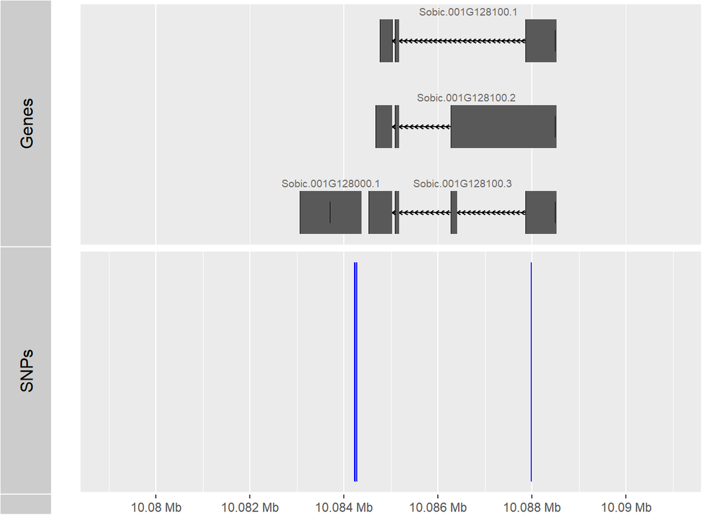

```r
myregion <- GRanges("Chr01", IRanges(10080000, 10090000))
p.genes <- autoplot(sorghumTxDb, which = myregion)
p.snps <- autoplot(rowRanges(sorghumVCF), geom = "rect", col = "blue") + xlim(myregion)

tracks(Genes = p.genes, SNPs = p.snps)
```

We could change the value of `myregion` to explore other regions. You may also want to look at packages like `rtracklayer`, `Gviz`, `trackViewer`, and `Sushi`.